# Temporal trends in treatment patterns of systemic lupus erythematosus in Sweden - material to poster P150 at the 14th European Lupus Meeting 2024

Annica Dominicus<sup>1,✉</sup>, Arthur Mageau<sup>1,2</sup>, Ngoc V. Nguyen<sup>1</sup>, Elisabet Svenungsson<sup>3</sup>, and Elizabeth V. Arkema<sup>1</sup>

14 March, 2024

<sup>1</sup> Clinical Epidemiology Division, Department of Medicine Solna, Karolinska Institutet  
<sup>2</sup> Infection, Antimicrobials Modelling Evolution, Université de Paris, Paris, France  
<sup>3</sup> Division of Rheumatology, Department of Medicine Solna, Karolinska Institutet, Karolinska University Hospital, Stockholm, Sweden

<sup>✉</sup> Correspondence: Annica Dominicus <annica.dominicus@ki.se>

[figure not shown]

# Introduction

The current document provides additional results from the analysis of temporal trends in treatment patterns of SLE patients in Sweden described in Poster P150 at the 14th European Lupus Meeting 2024.

The study aim is to examine temporal trends in treatment patterns of systemic lupus erythematosus (SLE) patients in Sweden and how treatment patterns are related to patient characteristics. We focus on prescribed SLE treatments including Hydroxychloroquine (HCQ) , Glucocorticoids (GC), and DMARDs (AZA, MMF, MTX, CIC, CYC, SUL, LEF).

# Study population

The study population is identified from the Swedish National Patient Register (NPR) including all unique individuals with ≥2 visits listing an International Classification of Diseases (ICD) code for SLE in the NPR (M32, excluding drug-induced lupus M32.0), including at least one visit with a specialist (clinics/departments which typically diagnose SLE; rheumatology, dermatology, nephrology, internal medicine, and pediatrics). Incident cases are identified by restricting the population to patients with their first visit listing the ICD code for SLE between 2005-07-01 and 2021-09-01, allowing at least 4.5 years to exclude prevalent cases based on data from the NPR. The current study is restricted to patients with time between first visit listing the ICD code for SLE and confirmation of SLE diagnosis within 1 year to make cohorts defined by year of diagnosis comparable.

# Methods

Treatments were summarized in 1-year intervals in relation to time since SLE diagnosis and described in alluvial plots.

The proportion with any dispensation year 1 and 5 after SLE diagnosis was analysed for HCQ and GC separately based on logistic regression models including year of SLE diagnosis, age, sex, educational level, country of birth, hospital where receiving SLE diagnosis (university/other), number of hospitalizations, and number of out-patient visits during the preceding year as covariates.

Cumulative GC dose over the first five years after diagnosis was analysed by quantile regression, evaluating quantiles in the range 10%-90% and the association to patient characteristics. To acknowledge that guidelines for GC dose is in relation to weight, the interaction between sex and year of diagnosis was included in the model in addition to the patient charactersistics listed above.

# Results

Patient characteristics of incident SLE cases, stratified on SLE diagnosis year, is shown in Table 1.

Table 1: Patient characteristics of incident cases by year of SLE diagnosis.

|  | 2005-2008 (N=884) | 2009-2012 (N=1071) | 2013-2016 (N=1041) | 2017-2021 (N=1230) | Total (N=4226) |
| --- | --- | --- | --- | --- | --- |
| Sex |  |  |  |  |  |
| Female | 743 (84.0%) | 893 (83.4%) | 854 (82.0%) | 1010 (82.1%) | 3500 (82.8%) |
| Male | 141 (16.0%) | 178 (16.6%) | 187 (18.0%) | 220 (17.9%) | 726 (17.2%) |
| Age at SLE diagnosis (years) |  |  |  |  |  |
| Mean (SD) | 48.8 (17.9) | 48.7 (17.8) | 49.0 (18.4) | 48.3 (18.7) | 48.7 (18.2) |
| Median [Min, Max] | 48.0 [18.0, 94.0] | 48.0 [18.0, 90.0] | 47.0 [18.0, 95.0] | 46.0 [18.0, 96.0] | 47.0 [18.0, 96.0] |
| Age at SLE diagnosis (years) |  |  |  |  |  |
| 18-39 | 306 (34.6%) | 376 (35.1%) | 362 (34.8%) | 487 (39.6%) | 1531 (36.2%) |
| 40-59 | 312 (35.3%) | 359 (33.5%) | 330 (31.7%) | 356 (28.9%) | 1357 (32.1%) |
| >=60 | 266 (30.1%) | 336 (31.4%) | 349 (33.5%) | 387 (31.5%) | 1338 (31.7%) |
| Country of birth |  |  |  |  |  |
| Nordic | 753 (85.2%) | 877 (81.9%) | 807 (77.5%) | 918 (74.6%) | 3355 (79.4%) |
| Non-Nordic | 117 (13.2%) | 183 (17.1%) | 214 (20.6%) | 288 (23.4%) | 802 (19.0%) |
| Missing | 14 (1.6%) | 11 (1.0%) | 20 (1.9%) | 24 (2.0%) | 69 (1.6%) |
| SLE diagnosis |  |  |  |  |  |
| University hospital | 448 (50.7%) | 532 (49.7%) | 529 (50.8%) | 571 (46.4%) | 2080 (49.2%) |
| Other hospital | 436 (49.3%) | 539 (50.3%) | 512 (49.2%) | 659 (53.6%) | 2146 (50.8%) |
| Educational level |  |  |  |  |  |
| 0-9y | 236 (26.7%) | 261 (24.4%) | 216 (20.7%) | 181 (14.7%) | 894 (21.2%) |
| 10-12y | 378 (42.8%) | 443 (41.4%) | 443 (42.6%) | 433 (35.2%) | 1697 (40.2%) |
| >=13y | 253 (28.6%) | 335 (31.3%) | 353 (33.9%) | 416 (33.8%) | 1357 (32.1%) |
| Missing | 17 (1.9%) | 32 (3.0%) | 29 (2.8%) | 200 (16.3%) | 278 (6.6%) |
| Hospitalizations (BL) |  |  |  |  |  |
| Mean (SD) | 0.792 (1.60) | 0.778 (1.51) | 0.821 (1.55) | 0.630 (1.28) | 0.748 (1.48) |
| Median [Min, Max] | 0 [0, 23.0] | 0 [0, 16.0] | 0 [0, 15.0] | 0 [0, 13.0] | 0 [0, 23.0] |
| Outpatient visits (BL) |  |  |  |  |  |
| Mean (SD) | 4.42 (6.11) | 4.89 (6.84) | 5.43 (6.70) | 5.33 (5.81) | 5.05 (6.38) |
| Median [Min, Max] | 3.00 [0, 112] | 3.00 [0, 156] | 4.00 [0, 129] | 4.00 [0, 72.0] | 3.00 [0, 156] |
| Reason for end of follow-up |  |  |  |  |  |
| Censored | 652 (73.8%) | 852 (79.6%) | 895 (86.0%) | 1150 (93.5%) | 3549 (84.0%) |
| Death | 232 (26.2%) | 219 (20.4%) | 146 (14.0%) | 80 (6.5%) | 677 (16.0%) |
| Follow-up time (years) |  |  |  |  |  |
| Mean (SD) | 13.5 (4.34) | 10.5 (3.14) | 7.28 (1.98) | 3.37 (1.42) | 8.26 (4.71) |
| Median [Min, Max] | 15.0 [0.0219, 17.3] | 11.2 [0.0657, 13.8] | 7.57 [0.0438, 9.85] | 3.38 [0.0219, 5.85] | 7.93 [0.0219, 17.3] |

BL=baseline period of 1 year preceding SLE diagnosis.

Initial treatment of SLE, captured by dispensations the first year after first SLE diagnosis, and long term use, as measured by dispensations the fifth year after SLE diagnosis, and how this has changed over calendar time is described in Table 2.

Table 2: HCQ, GC, and DMARD use 1st and 5th year after SLE diagnosis.

|  |  | 2005-2008 | 2009-2012 | 2013-2016 | 2017-2021 |
| --- | --- | --- | --- | --- | --- |
| Year 1 | Oberved | (N=866) | (N=1044) | (N=1019) | (N=1195) |
|  | Glucocorticoids (GC) | 590 (68.1%) | 766 (73.4%) | 741 (72.7%) | 814 (68.1%) |
|  | Hydroxychloroquine (HCQ) | 388 (44.8%) | 665 (63.7%) | 744 (73.0%) | 960 (80.3%) |
|  | DMARD | 334 (38.6%) | 422 (40.4%) | 417 (40.9%) | 491 (41.1%) |
| Year 5 | Oberved | (N=801) | (N=970) | (N=946) | - |
|  | Glucocorticoids (GC) | 431 (53.8%) | 490 (50.5%) | 442 (46.7%) | - |
|  | Hydroxychloroquine (HCQ) | 330 (41.2%) | 508 (52.4%) | 573 (60.6%) | - |
|  | DMARD | 259 (32.3%) | 330 (34.0%) | 334 (35.3%) | - |

The alluvial plot, stratified by year of SLE diagnosis, in Figure 1 shows how patients transition from one year to the next in terms of combinations of treatments.

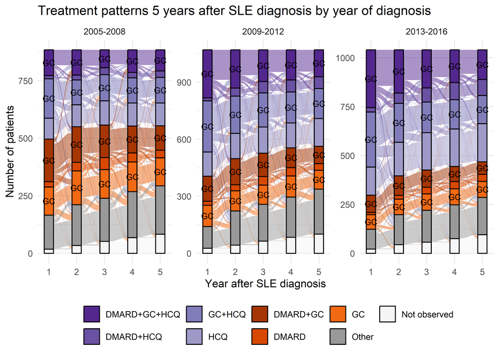

Figure 1: Combinations of treatments first 5 years after SLE diagnosis.

The association with year of diagnosis, evaluated in separate analyses for HCQ and GC at year 1 and 5 after SLE diagnosis, is summarized in Table 3.

Table 3: Analysis of temporal trends in HCQ and GC use 1st and 5th year after SLE diagnosis.

| Treatment | Year | Diagnosis year | OR |
| --- | --- | --- | --- |
| HCQ | Year 1 | 2005-2008 | - |
|  |  | 2009-2012 | 2.37 (1.95-2.88, p<0.001) |
|  |  | 2013-2016 | 3.83 (3.12-4.71, p<0.001) |
|  |  | 2017-2021 | 5.41 (4.37-6.73, p<0.001) |
| HCQ | Year 5 | 2005-2008 | - |
|  |  | 2009-2012 | 1.60 (1.31-1.95, p<0.001) |
|  |  | 2013-2016 | 2.23 (1.82-2.72, p<0.001) |
| GC | Year 1 | 2005-2008 | - |
|  |  | 2009-2012 | 1.22 (1.00-1.50, p=0.054) |
|  |  | 2013-2016 | 1.20 (0.98-1.47, p=0.083) |
|  |  | 2017-2021 | 0.98 (0.80-1.21, p=0.879) |
| GC | Year 5 | 2005-2008 | - |
|  |  | 2009-2012 | 0.83 (0.68-1.01, p=0.064) |
|  |  | 2013-2016 | 0.74 (0.61-0.91, p=0.003) |

Analyses adjusted for age, sex, educational level, country of birth, hospital for SLE diagnosis (university/other), number of hospitalizations, and out-patient visits during the preceding 1 year.

83.9% of SLE cases have at least one dispensation of GC during follow-up. Average daily dose of GC (prednisone equivalent) by year since SLE diagnosis is shown in Figure 2.

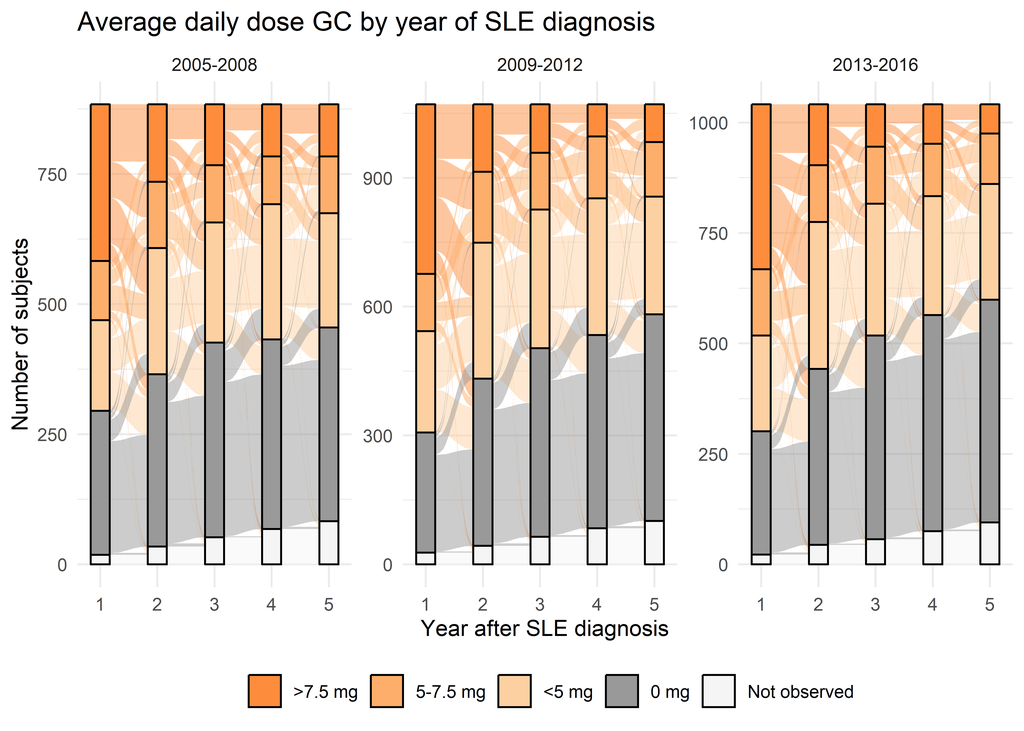

Figure 2: Average daily dose of GC first 5 years after SLE diagnosis.

Results from quantile regression analysis of the cumulative GC dose over the first 5 years after SLE diagnosis is shown in Figure 3. The reference group in the analysis is female, diagnosed 2005-2008, 50 yrs at diagnosis, education <10 yrs, Nordic country of birth, SLE diagnosis at non-university hospital, no hospitalizations and <3 out-patient visits during 1 year preceding diagnosis. Results shown include the estimated quantiles for this reference group and the difference in cumulative GC dose for patients with other characteristics.

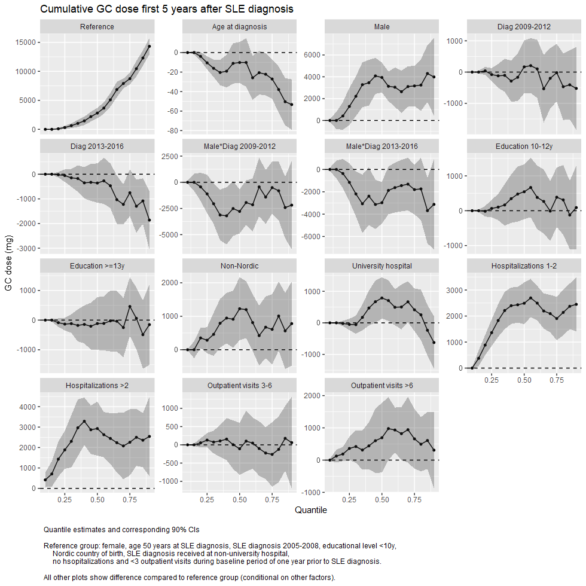

Figure 3: Quantile regression of cumulative GC dose the first 5 years after diagnosis.